# Conditional and Marginal Expectation and Variance

georges

15:54 21 September 2015

Generated: 15:54 21 September 2015

Derivation of function in Tcells package in file means_variances.R

The following are formulas and algorithms in R for the conditional and marginal expectations and variance of a T-cell process in which there is a hierarchy of cell types in which cells can transform from one type to the next type.

I am coding the algorithms in ‘STAN’, a probabilistic programming language for Bayesian inference which will allow an analysis in which the process at the level of the population is treated as a hidden Markov process. The resulting estimates, if the data is sufficient for this approach to work, may have a number of advantages over the HLM based only on modelling observed concentrations.

1. The analysis will take into account that concentrations, when used as covariates, are measured with error with consequent biasing of estimates of regression coefficients,
2. the HLM is implicitly based on the incorrect assumption that the conntrations are Markov thus ignoring potential information in concentrations measured prior to the previous occasion,
3. when a previous concentration is missing, the regression of a concentration on its precursors is lost although there is potential information from prior concentrations,
4. the analysis will combine both a ‘static’ model using equilibrium expectations and variances for the initial counts and the ‘dynamic’ model based on conditional expectations and variance for changes in population counts,
5. the model is based on a linear approximation to what is more like an exponential process: the linear approximation may be valid if one models relatively short time intervals between measurement occasions. The structural hidden Markov model for population counts can incorporate additional occasions to ‘bridge’ situations in which there is long delay between measurement occasions.
6. - others we’ll think of.

The downside is that I’m not sure the method will work on this amount of data. That will take simulations to explore.

## Expectation and variance for single cell type

$\begin{aligned} {X_{t + 1}} = & {X_t} + {N_t} + {B_t} - {D_t} \\ {N_t} \sim & \operatorname{Poisson} (\lambda ) \\ {B_t} \sim & \operatorname{Poisson} (\beta {X_t}) \\ {D_t} \sim & \operatorname{Poisson} (\delta {X_t}) \\ \operatorname{E} \left( {{X_{t + 1}}|{X_t}} \right) = & \lambda + \left( {1 + \beta - \delta } \right){X_t} \\ \operatorname{E} \left( {{X_{t + 1}}} \right) = & \lambda + \left( {1 + \beta - \delta } \right)\operatorname{E} \left( {{X_t}} \right) \\ \operatorname{E} (X) = & \lambda + \left( {1 + \beta - \delta } \right)\operatorname{E} \left( X \right) \\ \operatorname{E} (X) = & \frac{\lambda }{{\delta - \beta }} = \frac{\lambda }{\theta };\theta = \delta - \beta {\text{ is net death rate}} \\ \operatorname{Var} \left( {{X_{t + 1}}|{X_t}} \right) = & \lambda + \left( {\beta + \delta } \right){X_t} = \lambda + \alpha {X_t};\alpha = \beta + \delta {\text{ is the 'activity rate'}} \\ \operatorname{Var} \left( {{X_{t + 1}}} \right) = & \operatorname{E} \left( {\lambda + \alpha {X_t}} \right) + \operatorname{Var} \left( {\lambda + \left( {1 - \theta } \right){X_t}} \right) \\ = & \lambda + \alpha \operatorname{E} \left( {{X_t}} \right) + {\left( {1 - \theta } \right)^2}\operatorname{Var} \left( {{X_t}} \right) \\ \operatorname{Var} \left( X \right) = & \lambda + \alpha \operatorname{E} \left( X \right) + {\left( {1 - \theta } \right)^2}\operatorname{Var} \left( X \right) \\ \operatorname{Var} \left( X \right) = & \frac{{\lambda + \alpha \frac{\lambda }{\theta }}}{{1 - {{\left( {1 - \theta } \right)}^2}}} = \frac{{\frac{\lambda }{\theta }\left( {\theta + \alpha } \right)}}{{2\theta - {\theta ^2}}} = \frac{{\lambda \left( {\theta + \alpha } \right)}}{{{\theta ^2}\left( {2 - \theta } \right)}} \\ \end{aligned}$

```r
# Utility functions -----------------------------------------------------------------------------------

disp <- function (x)
{
  cat("\n::: ", deparse(substitute(x)), " :::\n")
  print(x)
}

# Functions for a single cell type --------------------------------------------------------------------
ceq1 <- function( lambda, beta, delta){
  theta <- delta - beta
  alpha <- delta + beta
  ret <- lambda / theta
  attr(ret, 'sd') <-  sqrt(lambda * (theta + alpha) / ( theta^2 * (2 - theta)))
  ret
}

ceq1(10, .01, .02)
```

```
|  [1] 1000
|  attr(,"sd")
|  [1] 44.83358
```

```r
sim1 <- function(N, lambda, beta, delta, burnin = 1000){
  start <- ceq1(lambda, beta, delta)
  if(start <= 0) stop('series not stationary')
  x <- rep(NA,N+burnin)
  x[1] <- round(start)
  for ( i in 2:(N+burnin)) {
    n <- rpois(1,lambda)
    b <- rpois(1,beta*x[i-1])
    d <- rpois(1,delta*x[i-1])
    x[i] <- x[i-1] + n + b - d
  }
  attr(x,'pars') <- list(lambda=lambda,beta=beta,delta=delta,ex=start)
  x
}

x <- sim1(10000, 10, .01, .02)
mean(x)
```

```
|  [1] 1013.638
```

```r
sd(x)
```

```
|  [1] 49.66612
```

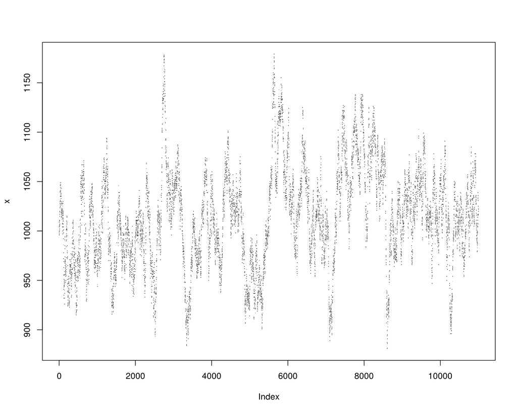

```r
plot(x,pch='.')
```

```r
ceq1(10,.01,.02)
```

```
|  [1] 1000
|  attr(,"sd")
|  [1] 44.83358
```

```r
# Simulate and test ---------------------------------------------------------------------------------
lam <- 10
beta <- .01
delta <- .02
ceq1(lam,beta,delta)
```

```
|  [1] 1000
|  attr(,"sd")
|  [1] 44.83358
```

```r
x <- sim1(10000, lam, beta, delta)
mean(x)
```

```
|  [1] 995.8586
```

```r
sd(x)
```

```
|  [1] 42.38339
```

## Three cell types

The following formulas and algorithms are general in that they can be applied to any number of cell types. Three is a minimal number in order to represent the full model with

1. a ‘Naive’ type that are can be created autonomously at a rate that is independent of the current population size,
2. one or more ‘transitory’ types that can be transformed into and that can transform into the next type, and
3. a ‘terminal’ type that does not transform.

### Definition of process

$\begin{aligned} {Y_{t + 1}} = & \left[ {\begin{array}{*{20}{c}} {{X_{1,t + 1}}} \\ {{X_{2,t + 1}}} \\ {{X_{3,t + 1}}} \end{array}} \right] = \left[ {\begin{array}{*{20}{c}} {{X_{1t}} + {N_t} + {B_{1t}} - {D_{1t}} - {T_{1t}}} \\ {{X_{2t}} + {T_{1t}} + {B_{2t}} - {D_{2t}} - {T_{2t}}} \\ {{X_{3t}} + {T_{2t}} + {B_{3t}} - {D_{3t}}} \end{array}} \right] \\ = & {Y_t} + \left[ {\begin{array}{*{20}{c}} {{N_t} + {B_{1t}} - {D_{1t}} - {T_{1t}}} \\ {{T_{1t}} + {B_{2t}} - {D_{2t}} - {T_{2t}}} \\ {{T_{2t}} + {B_{3t}} - {D_{3t}}} \end{array}} \right] \\ {\text{Given }}{Y_t}: & \\ {N_t} \sim & \operatorname{Poisson} \left( \lambda \right) \\ {B_{it}} \sim & \operatorname{Poisson} \left( {{\beta _i}{X_{it}}} \right) \\ {D_{it}} \sim & \operatorname{Poisson} \left( {{\delta _i}{X_{it}}} \right) \\ {T_{it}} \sim & \operatorname{Poisson} \left( {{\tau _i}{X_{it}}} \right) \\ \end{aligned}$

In the following we define: $\begin{aligned} {\theta _i} = & {\delta _i} + {\tau _i} - {\beta _i} \\ {\alpha _i} = & {\delta _i} + {\tau _i} + {\beta _i} \\ \end{aligned}$ for $i = 1,...,I-1$, and $\begin{aligned} {\theta _I} = & {\delta _I} - {\beta _I} \\ {\alpha _I} = & {\delta _I} + {\beta _I} \\ \end{aligned}$

Note that $\theta_i$ and $\alpha_i$ represent the ‘net conditional death rate’ and a ‘conditional activity rate’ respectively.

### Expected value of process

$\begin{aligned} \operatorname{E} \left( {{Y_{t + 1}}|{Y_t}} \right) = & \operatorname{E} \left( {\left. {\begin{array}{*{20}{c}} {{X_{1,t + 1}}} \\ {{X_{2,t + 1}}} \\ {{X_{3,t + 1}}} \end{array}} \right|} \right.\left. {\begin{array}{*{20}{c}} {{X_{1t}}} \\ {{X_{2t}}} \\ {{X_{3t}}} \end{array}} \right) = \operatorname{E} \left( {\left. {\begin{array}{*{20}{c}} {{X_{1t}} + {N_t} + {B_{1t}} - {D_{1t}} - {T_{1t}}} \\ {{X_{2t}} + {T_{1t}} + {B_{2t}} - {D_{2t}} - {T_{2t}}} \\ {{X_{3t}} + {T_{2t}} + {B_{3t}} - {D_{3t}}} \end{array}} \right|} \right.\left. {\begin{array}{*{20}{c}} {{X_{1t}}} \\ {{X_{2t}}} \\ {{X_{3t}}} \end{array}} \right) \\ = & \left[ {\begin{array}{*{20}{c}} \lambda \\ 0 \\ 0 \end{array}} \right] + \left[ {\begin{array}{*{20}{c}} {1 - {\theta _1}}&0&0 \\ {{\tau _1}}&{1 - {\theta _2}}&0 \\ 0&{{\tau _2}}&{1 - {\theta _3}} \end{array}} \right]\left[ {\begin{array}{*{20}{c}} {{X_{1t}}} \\ {{X_{2t}}} \\ {{X_{3t}}} \end{array}} \right] \\ = & \left[ {\begin{array}{*{20}{c}} \lambda \\ 0 \\ 0 \end{array}} \right] + \left[ {\begin{array}{*{20}{c}} {1 - {\theta _1}}&0&0 \\ {{\tau _1}}&{1 - {\theta _2}}&0 \\ 0&{{\tau _2}}&{1 - {\theta _3}} \end{array}} \right]{Y_t} \\ \operatorname{E} \left( {{Y_{t + 1}}} \right) = & \left[ {\begin{array}{*{20}{c}} \lambda \\ 0 \\ 0 \end{array}} \right] + \left[ {\begin{array}{*{20}{c}} {1 - {\theta _1}}&0&0 \\ {{\tau _1}}&{1 - {\theta _2}}&0 \\ 0&{{\tau _2}}&{1 - {\theta _3}} \end{array}} \right]\operatorname{E} \left( {{Y_t}} \right) \\ \operatorname{E} (Y) = & {\left\{ {I - \left[ {\begin{array}{*{20}{c}} {1 - {\theta _1}}&0&0 \\ {{\tau _1}}&{1 - {\theta _2}}&0 \\ 0&{{\tau _2}}&{1 - {\theta _3}} \end{array}} \right]} \right\}^{ - 1}}\left[ {\begin{array}{*{20}{c}} \lambda \\ 0 \\ 0 \end{array}} \right] \\ = & {\left[ {\begin{array}{*{20}{c}} {{\theta _1}}&0&0 \\ { - {\tau _1}}&{{\theta _2}}&0 \\ 0&{ - {\tau _2}}&{{\theta _3}} \end{array}} \right]^{ - 1}}\left[ {\begin{array}{*{20}{c}} \lambda \\ 0 \\ 0 \end{array}} \right] \\ = & \lambda \left[ {\begin{array}{*{20}{c}} {\theta _1^{ - 1}} \\ {{\tau _1}\theta _1^{ - 1}\theta _2^{ - 1}} \\ {{\tau _1}{\tau _2}\theta _1^{ - 1}\theta _2^{ - 1}\theta _3^{ - 1}} \end{array}} \right] \end{aligned}$

### Variance of process

#### Mean conditional variance

$\begin{aligned} \operatorname{Var} \left( {{Y_{t + 1}}|{Y_t}} \right) = & \operatorname{Var} \left( {\left. {\begin{array}{*{20}{c}} {{X_{1,t + 1}}} \\ {{X_{2,t + 1}}} \\ {{X_{3,t + 1}}} \end{array}} \right|} \right.\left. {\begin{array}{*{20}{c}} {{X_{1t}}} \\ {{X_{2t}}} \\ {{X_{3t}}} \end{array}} \right)\\ = & \operatorname{Var} \left( {\left[ {\begin{array}{*{20}{c}} {{X_{1t}}} \\ {{X_{2t}}} \\ {{X_{3t}}} \end{array}} \right] + \left[ {\begin{array}{*{20}{c}} {{N_t} + {B_{1t}} - {D_{1t}} - {T_{1t}}} \\ {{T_{1t}} + {B_{2t}} - {D_{2t}} - {T_{2t}}} \\ {{T_{2t}} + {B_{3t}} - {D_{3t}}} \end{array}} \right]} \right| \left. {\begin{array}{*{20}{c}} {{X_{1t}}} \\ {{X_{2t}}} \\ {{X_{3t}}} \end{array}} \right) \\ = & \operatorname{Var} \left( {\left[ {\begin{array}{*{20}{c}} 1&1&{ - 1}&{ - 1}&0&0&0&0&0 \\ 0&0&0&1&1&{ - 1}&{ - 1}&0&0 \\ 0&0&0&0&0&0&1&1&{ - 1} \end{array}} \right]} \right.\left[ {\begin{array}{*{20}{c}} {{N_t}} \\ {{B_{1t}}} \\ {{D_{1t}}} \\ {{T_{1t}}} \\ {{B_{2t}}} \\ {{D_{2t}}} \\ {{T_{2t}}} \\ {{B_{3t}}} \\ {{D_{3t}}} \end{array}} \right]\left. {\left| {\begin{array}{*{20}{c}} {{X_{1t}}} \\ {{X_{2t}}} \\ {{X_{3t}}} \end{array}} \right.} \right) \\ = & C\left( {\left[ {\begin{array}{*{20}{c}} 1&1&{ - 1}&{ - 1}&0&0&0&0&0 \\ 0&0&0&1&1&{ - 1}&{ - 1}&0&0 \\ 0&0&0&0&0&0&1&1&{ - 1} \end{array}} \right],diag\left( {\lambda ,{\beta _1}{X_{1t}},{\delta _1}{X_{1t}},{\tau _1}{X_{1t}},{\beta _2}{X_{2t}},{\delta _2}{X_{2t}},{\tau _2}{X_{2t}},{\beta _3}{X_{3t}},{\delta _3}{X_{3t}}} \right)} \right) \\ \operatorname{E} \left( {\operatorname{Var} \left( {{Y_{t + 1}}|{Y_t}} \right)} \right) = & C\left( {\left[ {\begin{array}{*{20}{c}} 1&1&{ - 1}&{ - 1}&0&0&0&0&0 \\ 0&0&0&1&1&{ - 1}&{ - 1}&0&0 \\ 0&0&0&0&0&0&1&1&{ - 1} \end{array}} \right],\operatorname{E} \left( {diag\left( {\lambda ,{\beta _1}{X_{1t}},{\delta _1}{X_{1t}},{\tau _1}{X_{1t}},{\beta _2}{X_{2t}},{\delta _2}{X_{2t}},{\tau _2}{X_{2t}},{\beta _3}{X_{3t}},{\delta _3}{X_{3t}}} \right)} \right)} \right) \\ & {\text{where }}C\left( {A,B} \right) = ABA' \\ \end{aligned}$

#### Variance of conditional mean

$\begin{aligned} \operatorname{Var} \left( {\operatorname{E} \left( {{Y_{t + 1}}|{Y_t}} \right)} \right) = & \operatorname{Var} \left( {\left[ {\begin{array}{*{20}{c}} {1 - {\theta _1}}&0&0 \\ {{\tau _1}}&{1 - {\theta _2}}&0 \\ 0&{{\tau _2}}&{1 - {\theta _3}} \end{array}} \right]{Y_t}} \right) = \left[ {\begin{array}{*{20}{c}} {1 - {\theta _1}}&0&0 \\ {{\tau _1}}&{1 - {\theta _2}}&0 \\ 0&{{\tau _2}}&{1 - {\theta _3}} \end{array}} \right]\operatorname{Var} \left( {{Y_t}} \right){\left[ {\begin{array}{*{20}{c}} {1 - {\theta _1}}&0&0 \\ {{\tau _1}}&{1 - {\theta _2}}&0 \\ 0&{{\tau _2}}&{1 - {\theta _3}} \end{array}} \right]^\prime } \\ \operatorname{Var} \left( {{Y_{t + 1}}} \right) = & P + Q\operatorname{Var} \left( {{Y_t}} \right)Q' \\ \end{aligned}$

Thus the variance of the process, $\operatorname{Var} \left( {Y} \right)$, if it exists, is the solution to the equation:

$\operatorname{Var} \left( Y \right) = P + L\operatorname{Var} \left( Y \right)L'$

where $P$ is the mean conditional variance and $Q$ is a lower triangular matrix. In one dimension, the solution is analogous to the well known solution for the sum of a geometric sequence.

To find a solution to the matrix version, we exploit the fact that $L$ is lower triangular with, if the process is stationary, distinct eigenvalues. Thus, it is easily diagnalized, as shown below, with $L = GDG^{-1}$ where $D$ is diagonal.

#### Solution of *V = A + LVL’*

I think that the following works (check details) if $||L|| < 1$. Consider:

$\begin{aligned} V = & A + LVL' \\ = & A + L \left( A + LVL' \right)L'\\ = & A + LAL' + L^2\left( A + LVL' \right)L'^2\\ = & A + LAL' + L^2AL'^2 + ... + L^nAL'^n + L^{n+1}VL'^{n+1}\\ = & A + LAL' + L^2AL'^2 + ... + L^nAL'^n + ...\\ \end{aligned}$

If $L = GDG^{-1}$, then

$V = A + GDG^{-1}AG'^{-1}DG'+ GD^2G^{-1}AG'^{-1}D^2G'+ GD^3G^{-1}AG'^{-1}D^3G' +...$

Letting $B = G^{-1}AG'^{-1}$:

$V = G(B + DBD + D^2BD^2 + D^3BD^3 + D^4BD^4 +... )G'$

Each term of $K = B + DBD + D^2BD^2 + D^3BD^3 + D^4BD^4 +...$ has the form:

$\begin{aligned} K_{jk} = & B_{jk} + D_{jj}B_{jk}D_{kk} + D_{jj}^2B_{jk}D_{kk}^2 + D^3_{jj}B_{jk}D^3_{kk} + D_{jj}^4B_{jk}D_{kk}^4 +...\\ = & B_{jk} + D_{jj}D_{kk}B_{jk} + (D_{jj}D_{kk})^2B_{jk} + (D_{jj}D_{kk})^3B_{jk} + (D_{jj}D_{kk})^4B_{jk} +...\\ = & B_{jk} + \phi_{jk}B_{jk} + \phi_{jk}^2B_{jk} + \phi_{jk}^3B_{jk} + \phi_{jk}^4B_{jk} +...\\ \end{aligned}$

Thus, if the geometric series converges:

$K_{jk} = \frac{B_{jk}}{1-D_{jj}D_{kk}}$

and

$V = GKG'$

Ultimately, this algorithm needs to be programmed in STAN since it needs to be used for the evaluation of the ‘equilibrium’ likelihood in which likelihood is evaluated on the assumption that the starting profile reflects the process in equilibrium.

To check the derivation, we program the algorithm in R and will check its accuracy through simulation.

```r
# Conditional expectation ---------

cond_ev <- function(Y, lambda = parms$lambda,
                    birth = parms$birth,
                    death = parms$death,
                    tran = parms$tran,
                    parms, # optional way of providing parameters
                    verbose = FALSE){
  # Returns: E( Y_{t+1} | Y_t)
  N <- length(Y)
  # birth, death and trans can be entered as single value
  birth <- rep(birth, length.out = N)
  death <- rep(death, length.out = N)
  if (N > 1) tran <- rep(tran, length.out = N-1)
  # net death rate
  theta <- numeric(N)
  if(N == 1) theta[1] <- death[1] - birth[1]
  if(N > 1) {
    theta[1] <- death[1] - birth[1] + tran[1]
    if (N > 2) {
      for (i in 2:(N-1)) theta[i] <-
          death[i] + tran[i] - birth[i]
    }
    theta[N] <- death[N] - birth[N]
  }
  if(verbose) {
    disp(lambda)
    disp(birth)
    disp(death)
    disp(tran)
    disp(theta)
  }
  if(N == 1) L <- 1 - theta[1] else {
    L <- diag( 1 - theta)
    L[row(L)==(col(L)+1)] <- tran
  }
  if(verbose) disp(L)
  if(N == 1) return( lambda + L * Y)
  c(lambda,rep(0,N-1)) + L %*% Y
}


cond_ev(c(100,100,100), 10, .01, .03, c(.01,.02))
```

```
|       [,1]
|  [1,]  107
|  [2,]   97
|  [3,]  100
```

```r
parms <- list(lambda = 10, birth = rep(.01,3),
              death = .03, tran = c(.01,.02))
cond_ev(c(100,100,100), parms = parms)
```

```
|       [,1]
|  [1,]  107
|  [2,]   97
|  [3,]  100
```

```r
Nsteps <- 2000
mat <- matrix(NA, 3, Nsteps)
mat[,1] <- c(100,100,100)
for ( i in 2:Nsteps) mat[,i] <- cond_ev(mat[,i-1],parms = parms)
# Equilibrium profile with these parameters:
head(t(mat),10)
```

```
|            [,1]      [,2]      [,3]
|   [1,] 100.0000 100.00000 100.00000
|   [2,] 107.0000  97.00000 100.00000
|   [3,] 113.7900  94.19000  99.94000
|   [4,] 120.3763  91.56030  99.82500
|   [5,] 126.7650  89.10165  99.65971
|   [6,] 132.9621  86.80524  99.44854
|   [7,] 138.9732  84.66265  99.19568
|   [8,] 144.8040  82.66587  98.90502
|   [9,] 150.4599  80.80728  98.58024
|  [10,] 155.9461  79.07959  98.22478
```

```r
tail(t(mat),10)
```

```
|              [,1]     [,2]     [,3]
|  [1991,] 333.3333 83.33333 83.33333
|  [1992,] 333.3333 83.33333 83.33333
|  [1993,] 333.3333 83.33333 83.33333
|  [1994,] 333.3333 83.33333 83.33333
|  [1995,] 333.3333 83.33333 83.33333
|  [1996,] 333.3333 83.33333 83.33333
|  [1997,] 333.3333 83.33333 83.33333
|  [1998,] 333.3333 83.33333 83.33333
|  [1999,] 333.3333 83.33333 83.33333
|  [2000,] 333.3333 83.33333 83.33333
```

```r
# matplot(t(mat), type = 'l')

# Marginal (equilibrium) expectation -------------------

marg_ev <- function(lambda = parms$lambda,
                    birth = parms$birth,
                    death = parms$death,
                    tran = parms$tran,
                    parms, # optional way of providing parameters
                    verbose = FALSE) {
  # Returns: E( Y ) at equilibrium
  N <- length(birth)  # must have correct length
  # death and trans can be entered as single value
  death <- rep(death, length.out = N)
  if (N > 1) tran <- rep(tran, length.out = N-1)
  # net death rate
  theta <- numeric(N)
  if(N == 1) theta[1] <- death[1] - birth[1]
  if(N > 1) {
    theta[1] <- death[1] - birth[1] + tran[1]
    if (N > 2) {
      for (i in 2:(N-1)) theta[i] <-
          death[i] + tran[i] - birth[i]
    }
    theta[N] <- death[N] - birth[N]
  }
  ret <- numeric(N)
  ret[1] <- lambda / theta[1]
  if ( N > 1) for ( i in 2:N) ret[i] <-
    ret[i-1] * tran[i-1]/theta[i]
  ret
}

marg_ev(parms=parms)
```

```
|  [1] 333.33333  83.33333  83.33333
```

```r
# By simulation

mat[,1]
```

```
|  [1] 100 100 100
```

```r
mat[,10]
```

```
|  [1] 155.94609  79.07959  98.22478
```

```r
mat[,100]
```

```
|  [1] 321.8946  76.2879  74.7523
```

```r
mat[,500]
```

```
|  [1] 333.33327  83.33328  83.32508
```

```r
mat[,1000]
```

```
|  [1] 333.33333  83.33333  83.33333
```

```r
# Conditional variance ----------

cond_var <- function(Y,
                     lambda = parms$lambda,
                     birth = parms$birth,
                     death = parms$death,
                     tran = parms$tran,
                     parms, # optional way of providing parameters
                     verbose = FALSE) {
  # Returns: Var( Y_{t+1} | Y_t) = T D T'
  # where D is diagonal matrix of variances of new cell births, deaths and transitions
  N <- length(Y)
  # birth, death and trans can be entered as single value
  birth <- rep(birth, length.out = N)
  death <- rep(death, length.out = N)
  if (N > 1) tran <- rep(tran, length.out = N-1)
  # D
  D <- numeric(3*N)
  D <- c(lambda, birth[1]*Y[1], death[1]*Y[1])
  if(N > 1) {
    for (i in 2:N) {
      D[3*i-2] <- tran[i-1]*Y[i-1]
      D[3*i-1] <- birth[i]*Y[i]
      D[3*i] <- death[i]*Y[i]
    }
  }
  if(verbose) disp(D)
  # L matrix
  L <- matrix(0,N,3*N+1) # will drop last column
  for (i in 1:N) L[i,(3*i-2):(3*i+1)] <- c(1,1,-1,-1)
  L <- L[,-(3*N+1)] # drop last column
  if(verbose) disp(L)
  L %*% ( D * t(L))
}

cond_var(c(100,100,100), parms = parms, verbose = T)
```

```
|  :::  D  :::
|  [1] 10  1  3  1  1  3  2  1  3
|  :::  L  :::
|       [,1] [,2] [,3] [,4] [,5] [,6] [,7] [,8] [,9]
|  [1,]    1    1   -1   -1    0    0    0    0    0
|  [2,]    0    0    0    1    1   -1   -1    0    0
|  [3,]    0    0    0    0    0    0    1    1   -1
```

```
|       [,1] [,2] [,3]
|  [1,]   15   -1    0
|  [2,]   -1    7   -2
|  [3,]    0   -2    6
```

```r
# Marginal (equilbrium) variance --------------------------------------------------------------------

# Eigenvectors of lower triangular matrix -----------------------------------------------------------
evec_lt <- function(A){
  # eigenvectors of a lower triangular matrix
  # return E where A = E %*% diag(A) %*% E^{-1}
  # Note that diag(A) is the diagonal matrix of eigenvectors (not ordered)
  N <- nrow(A)
  ret <- diag(N)
  for ( i in (N-1):1) {
    inds <- (i+1):N
    ret[inds,i] <- solve(A[inds,inds]-A[i,i]*diag(N-i),-A[inds,i])
  }
  ret
}
# Check evec_lt
A <- matrix(rnorm(25), 5,5)
A[col(A) > row(A)] <- 0
A
```

```
|              [,1]        [,2]        [,3]       [,4]      [,5]
|  [1,]  1.62862631  0.00000000  0.00000000  0.0000000 0.0000000
|  [2,] -0.10334168 -0.14260804  0.00000000  0.0000000 0.0000000
|  [3,]  0.06447669  0.11881502 -0.24756157  0.0000000 0.0000000
|  [4,] -1.87864552 -0.02451376 -0.07539143  1.7607831 0.0000000
|  [5,] -1.75807277  0.54382697  2.29502170 -0.9481543 0.8434168
```

```r
evec_lt(A) %*% diag(diag(A))- A %*% evec_lt(A)   # this should be machine 0
```

```
|                [,1]          [,2]          [,3] [,4] [,5]
|  [1,]  0.000000e+00  0.000000e+00  0.000000e+00    0    0
|  [2,]  0.000000e+00  0.000000e+00  0.000000e+00    0    0
|  [3,] -2.720046e-15 -5.551115e-17  0.000000e+00    0    0
|  [4,]  0.000000e+00 -3.469447e-18 -1.040834e-17    0    0
|  [5,]  0.000000e+00 -5.551115e-17  0.000000e+00    0    0
```

```r
# Solution to variance equation ------------------------------------------------------------------

var_equation <- function(A,L){
  # Returns V such that V = A + LVL' if a solution exists ??? (check conditions)
  # likely to return nonsense otherwise
  # This does for matrices what the formula for a geometric series does for scalars
  G <- evec_lt(L)  # this might not work although it probably should for reasonable
  # parameters for T-cells
  D <- diag(L)
  Ginv <- solve(G)
  # disp( L - G %*% (D* Ginv)) # ok
  B <- Ginv %*% A %*% t(Ginv)
  K <- B / (1 -outer(D,D))
  G %*% K %*% t(G)
}

A <- diag(3) + .1
A
```

```
|       [,1] [,2] [,3]
|  [1,]  1.1  0.1  0.1
|  [2,]  0.1  1.1  0.1
|  [3,]  0.1  0.1  1.1
```

```r
L <- cbind( c(.8,.1,.1), c(0, .7, .1), c(0,0,.6))
L
```

```
|       [,1] [,2] [,3]
|  [1,]  0.8  0.0  0.0
|  [2,]  0.1  0.7  0.0
|  [3,]  0.1  0.1  0.6
```

```r
V <- var_equation(A,L)
V
```

```
|            [,1]      [,2]      [,3]
|  [1,] 3.0555556 0.7828283 0.7828283
|  [2,] 0.7828283 2.4316696 0.7075317
|  [3,] 0.7828283 0.7075317 2.1083938
```

```r
V - A - L%*% V %*% t(L)  # should be machine 0
```

```
|               [,1]         [,2]         [,3]
|  [1,] 0.000000e+00 3.330669e-16 1.110223e-16
|  [2,] 3.330669e-16 6.661338e-16 7.771561e-16
|  [3,] 1.110223e-16 6.661338e-16 4.440892e-16
```

```r
# Variance of conditional mean --------------------------------------------------------------------

# Mean conditional variance

mean_cond_var <- function(
  lambda = parms$lambda,
  birth = parms$birth,
  death = parms$death,
  tran = parms$tran,
  parms, # optional way of providing parameters
  verbose = FALSE) {
  # Returns: E ( Var( Y_{t+1} | Y_t)) = T E(D) T'
  # where D is diagonal matrix of variances of new cell births, deaths and transitions
  EY <- marg_ev(lambda=lambda,birth=birth,death=death,tran=tran)
  cond_var(EY,lambda=lambda,birth=birth,death=death,tran=tran)
}

mean_cond_var(parms = parms)
```

```
|            [,1]      [,2]      [,3]
|  [1,] 26.666667 -3.333333  0.000000
|  [2,] -3.333333  8.333333 -1.666667
|  [3,]  0.000000 -1.666667  5.000000
```

```r
# Marginal variance --------------------------------------------------------------

marg_var <- function(
  lambda = parms$lambda,
  birth = parms$birth,
  death = parms$death,
  tran = parms$tran,
  parms, # optional way of providing parameters
  verbose = FALSE) {
  # Returns: Var (Y)
  N <- length(birth)  # must have correct length
  # death and trans can be entered as single value
  death <- rep(death, length.out = N)
  if (N > 1) tran <- rep(tran, length.out = N-1)
  # net death rate
  theta <- numeric(N)
  if(N == 1) theta[1] <- death[1] - birth[1]
  if(N > 1) {
    theta[1] <- death[1] - birth[1] + tran[1]
    if (N > 2) {
      for (i in 2:(N-1)) theta[i] <-
          death[i] + tran[i] - birth[i]
    }
    theta[N] <- death[N] - birth[N]
  }
  P <- mean_cond_var(lambda=lambda,birth=birth,death=death,tran=tran)
  if(N == 1) return(P/(2*theta[1] - theta[1]^2))
  L <- diag(1 - theta)
  L[row(L)==(col(L)+1)] <- tran
  var_equation(P, L)
}

marg_var(parms = parms)
```

```
|             [,1]       [,2]       [,3]
|  [1,] 451.212634  15.166122   5.955927
|  [2,]  15.166122 110.582196   8.748527
|  [3,]   5.955927   8.748527 136.039776
```

```r
# Simulation tests --------------------------------------------------------------------------------------

sim_step <- function(Y,
                     lambda = parms$lambda,
                     birth = parms$birth,
                     death = parms$death,
                     tran = parms$tran,
                     parms, # optional way of providing parameters
                     verbose = FALSE) {
  N <- length(Y)  # must have correct length
  # death and trans can be entered as single value
  birth <- rep(birth, length.out = N)
  death <- rep(death, length.out = N)
  if (N > 1) tran <- rep(tran, length.out = N-1)
  D <- numeric(3*N)
  D <- c(lambda, birth[1]*Y[1], death[1]*Y[1])
  if(N > 1) {
    for (i in 2:N) {
      D[3*i-2] <- tran[i-1]*Y[i-1]
      D[3*i-1] <- birth[i]*Y[i]
      D[3*i] <- death[i]*Y[i]
    }
  }
  if(verbose) disp(D)
  # L matrix
  L <- matrix(0,N,3*N+1) # will drop last column
  for (i in 1:N) L[i,(3*i-2):(3*i+1)] <- c(1,1,-1,-1)
  L <- L[,-(3*N+1)] # drop last column
  if(verbose) disp(L)
  Diffs <- rpois(length(D), lambda = D)
  Y + L %*% Diffs
}

system.time(
  sim_step(c(100,100,100), parms = parms)
)
```

```
|     user  system elapsed
|        0       0       0
```

```r
system.time(
  sim_step(c(100,100,100), parms = parms)
)
```

```
|     user  system elapsed
|        0       0       0
```

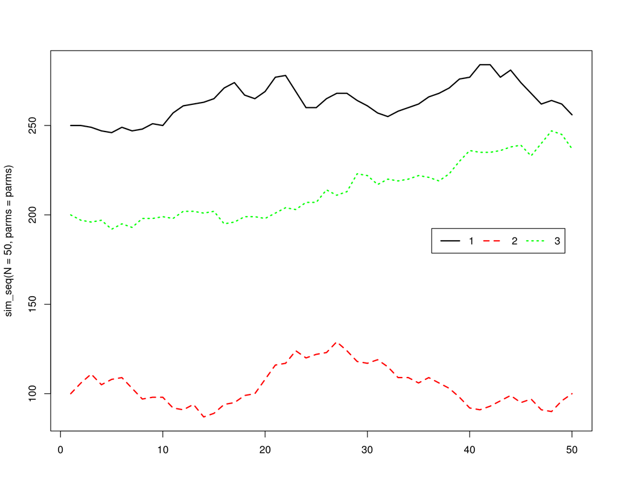

```r
sim_seq <- function(N, Y = marg_ev(lambda,birth,death,tran),
                    lambda = parms$lambda,
                    birth = parms$birth,
                    death = parms$death,
                    tran = parms$tran,
                    parms, # optional way of providing parameters
                    verbose = FALSE) {
  ret <- matrix(0,nrow = N, ncol = length(Y))
  ret[1,] <- Y
  if (N > 1) for ( i in 2:N) ret[i,] <- sim_step(ret[i-1,],
                                                 lambda = lambda,
                                                 birth = birth,
                                                 death = death,
                                                 tran = tran)
  ret
}

parms <- list(lambda=10, birth = c(.01,.02,.01), death = .03, tran = c(.02, .04))
matplot(sim_seq(N = 50, parms = parms), type = 'l', lty = c(1,2,3), lwd = 2, col = c('black','red','green'))
legend("right", inset=.05, legend=c("1", "2", "3"), lty = c(1,2,3), lwd = 2, col = c('black','red','green') , horiz=TRUE)
```

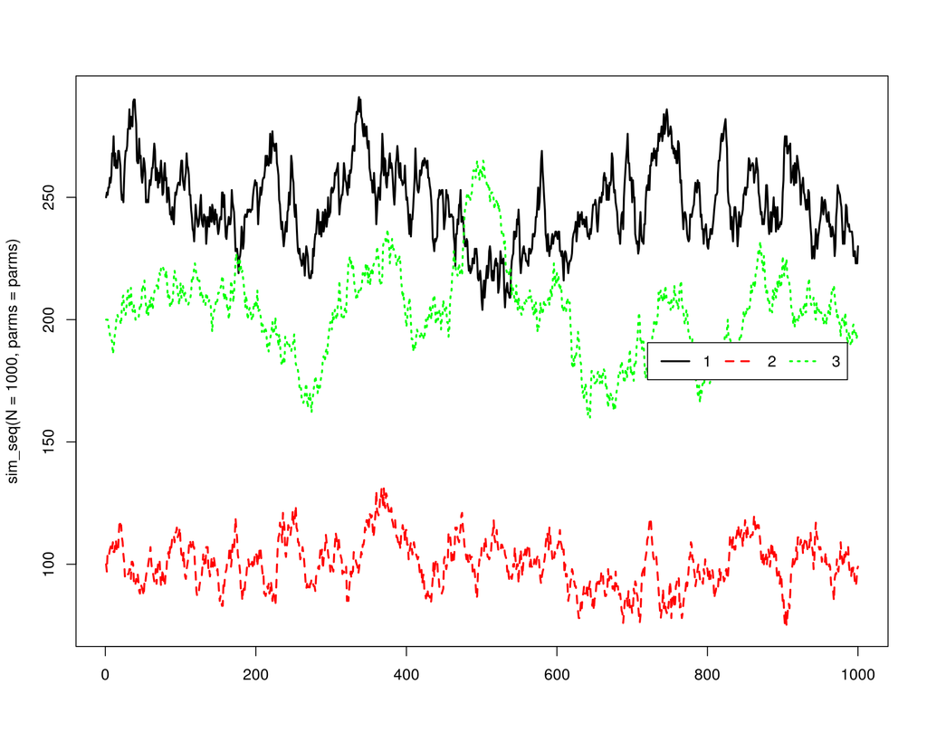

```r
matplot(sim_seq(N = 1000, parms = parms), type = 'l', lty = c(1,2,3), lwd = 2, col = c('black','red','green'))
legend("right", inset=.05, legend=c("1", "2", "3"), lty = c(1,2,3), lwd = 2, col = c('black','red','green') , horiz=TRUE)
```